# DataCheQC

Or Dotan

May 31st, 2023

## Overview

> **DataCheQC** is an interactive application based on the **R Shiny** framework developed for the purposes of performing quality control (QC) checks on pharmacometrics datasets, and thereby supporting the implementation of model-informed drug development.

> Features include **visual inspection** of variables and data entries for errors and/or anomalies, and **ensuring structural integrity** through comparison with a dataset specification file.

> The open-source app, which requires no programming knowledge to operate, also allows the user to collect all findings into a **summary QC Report** which can be downloaded directly from the app.

## The QC Workflow

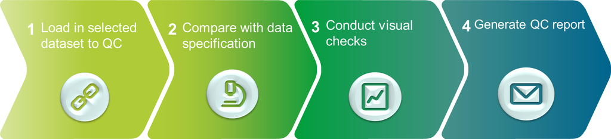

## Features

### Data Handling

- Automatic detection of doses, observations, and covariates
- Impute missing continuous covariate values
- Run data cleaning functions on the dataset

### Dataset Quality Checks

- Compare the dataset to the specification file’s general table
- Compare dataset observations with the specification file’s event table
- Filter out optional variables
- Check for missing or incorrectly defined values
- Check that corresponding columns aligned (e.g., Time and Nominal Time, Cohort and Dose, Value and Unit)
- Collect all findings into an editable QC report
- Download the final report as a *.docx* document
- Continue previous work by loading a pre-existing interim report

### Data Visualization and Summary Tables

- For Each Observation:
  - Spaghetti Plots
  - Median Range Plots
  - Individual Plots
- For Continuous/Categorical Covariates:
  - Covariate Distribution
  - Covariate Correlations
- For Timings:
  - Plots comparing Nominal vs Actual Time
  - Dosing Schedule plots
  - Sampling Schedule Plots
- Summary Tables:
  - Summary of Continuous & Categorical Covariates
  - Summary of Duplicated Time-Value Pairs
  - Summary of Observations
- All of the above can be downloaded separately or all together as .zip archive which will be built in the background

## Getting Started

To app is freely available online on [shinyapps.io](https://dotanor.shinyapps.io/DataCheQC/) and its source code is hosted as a public repository on [Github](https://github.com/DotanOr/DataCheQC).

### Local Installation

If you wish to run a local version of the app, run the following line in your R IDE:

```r
shiny::runGitHub("DotanOr/DataCheQC")
```

Alternatively, you can download the code as a .zip archive and extract the files, then run the app using:

```r
shiny::runApp("path/to/directory")
```